# Energy Prices in the United States

T Morrison

April 8, 2016

Continuing with the data from the EIA, I will be looking at some energy price data in the United States in this post. The data can be found [here](http://www.eia.gov/electricity/sales_revenue_price/) and contains information in the same format as the energy production data: year, state, industry sector category (see below), and price (cents/kilowatt hour) paid by different industries (residential, commercial, industrial, transportation).

Packages:

```r
library(readxl)
library(tidyr)
library(dplyr)
library(ggplot2)
library(data.table)
library(scales)
library(ggthemes)
library(maps)
```

Loading the data requires a transformation from wide to long format with the help of `tidyr` and the `gather()` function.

```r
priceYear <- read_excel("C:/Users/tmo/Desktop/R/priceannualenergy.xls", skip=1)
```

[output not shown]

```r
priceYear <- gather(priceYear, Sector, Price, -c(Year, State, `Industry Sector Category`))
priceYear<-data.table(priceYear)
```

Now we get

```r
head(priceYear)
```

```
##    Year State Industry Sector Category      Sector Price
## 1: 2014    AK  Total Electric Industry Residential 19.14
## 2: 2014    AL  Total Electric Industry Residential 11.48
## 3: 2014    AR  Total Electric Industry Residential  9.51
## 4: 2014    AZ  Total Electric Industry Residential  11.9
## 5: 2014    CA  Total Electric Industry Residential 16.25
## 6: 2014    CO  Total Electric Industry Residential 12.18
```

Some more steps:

Setting a `Region` column in the whole dataset using the update-by-reference (`:=`) capability of `data.table` and some nested `ifelse` statements. Also changing the column names and removing some outliers where the price was extremely high.

```r
priceYear[, Region := ifelse(State%in%MW, "Midwest", ifelse(State%in%W, "West", ifelse(State%in%S, "South", ifelse(State%in%NE, "Northeast", "US"))))]
rm(MW,W,S,NE)
names(priceYear)<-c("Year","State","Industry","Sector","Price","Region")
priceYear$Price<-as.numeric(priceYear$Price)
priceYear<-filter(priceYear, Price<40)
priceYear<-na.omit(priceYear)
priceYear<-filter(priceYear, Price!="NA")
```

Great!

```r
head(priceYear)
```

```
##    Year State                Industry      Sector Price Region
## 1: 2014    AK Total Electric Industry Residential 19.14   West
## 2: 2014    AL Total Electric Industry Residential 11.48  South
## 3: 2014    AR Total Electric Industry Residential  9.51  South
## 4: 2014    AZ Total Electric Industry Residential 11.90   West
## 5: 2014    CA Total Electric Industry Residential 16.25   West
## 6: 2014    CO Total Electric Industry Residential 12.18   West
```

### Deregulation overview

Many states in the US now have deregulated energy markets (covering electricity and/or gas), whereby the utilities’ legal monopolies on selling power are dismantled. This introduces competition and companies often entice new customers with guaranteed low rates or clean energy sources. Consumers then have the choice to choose a new supplier or continue purchasing energy from the utility (the default; though the utility will likely be purchasing the energy from independent producers since they have had to sell off their generation assets).

Without going into too much detail, consumers have to pay for the electricity as well as the delivery of it. Depending on the place, a consumer will have some different options here. The EIA breaks this down into these four categories in what is now the `Industry` column in our data (described [here](https://www.eia.gov/electricity/annual/html/epa_02_03.html) at the bottom of the page):

- Full-service energy providers: sell bundled delivery and energy services to end-use customers
- Restructured retail service providers: offer competitive pricing and source options to consumers
- Energy-only providers: sell energy to end-use customers
- Delivery-only service: sale of energy delivery to customer using energy-only providers (utility or other owner of distribution infrastructure)

I couldn’t find the distinction between restructured retail service providers and energy-only providers, but there are a lot of companies advertising themselves as retail service providers, while searching for “energy-only provider” did not turn up much. I’m not sure if there is any overlap between these categories or not, but I will not focus too much on energy-only providers as I’m sure the retail service provider price is combined supply and delivery while the other is not.

```r
dereg<- c("OR",
          "TX","MD","DC","DE",
          "IL","MI","OH",
          "NJ","NY","CT","RI","MA","NH","ME","PA")
priceYear[, Deregulated := ifelse(State %in% dereg, T, F)] #create 'Dereg' column for deregulated states
setkey(priceYear, Year)
```

It’s important to note that these deregulation efforts kicked in at different times across the country, if they did at all, so there will be some variation as to when the different types of energy providers start showing up in the graphics.

To start, here is a plot of the US average prices for the “Total Electric Industry” Industry Sector Category.

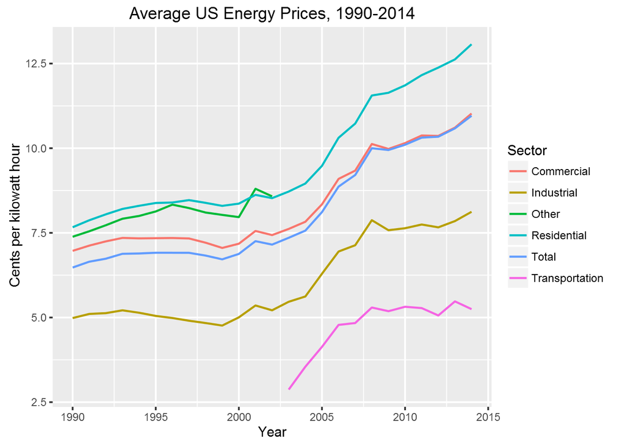

```r
ggplot(priceYear[Industry=="Total Electric Industry", mean(Price), by=.(Year, Sector)],
       aes(x=Year, y=V1, col=Sector)) +
  geom_line(size=.6) +
  ggtitle("Average US Energy Prices, 1990-2014") + ylab("Cents per kilowatt hour")
```

Next, I wanted to compare prices state by state. Knowing that a grid of fifty plots wouldn’t be easy to interpret, I put the idea off until I came across the mapping functions of ggplot2. I was able to use the built-in US map data and the `maps` package to get a blank state map that I could tie my price data to. The data ties together with a common variable in both the map data.frame and my price data.frame (the state name in this case).

```r
us <- map_data("state")
us$stateid<-us$region
```

I made a little function to input a year and get back a state-by-state projection with a color gradient for average energy price:

```r
priceYear$State <- tolower(state.name[match(priceYear$State,state.abb)])
priceYear$stateid <- priceYear$State

fun.stateplot <- function(year) {
  stateplot <- priceYear %>%
    filter(State!="HI") %>%
    filter(Year==year) %>%
    filter(Industry=="Total Electric Industry") %>%
    filter(Sector=="Residential")

  ggplot() +
    geom_map(data=us, map=us,
                      aes(x=long, y=lat, map_id=stateid), fill="#ffffff", color="#ffffff", size=0.15) +
    geom_map(data=stateplot, map=us,
             aes(fill=Price, map_id=stateid), color="#ffffff", size=.15) +
    scale_fill_continuous(low='red', high='blue', guide='colorbar') +
    labs(x=NULL, y=NULL) +
    theme(panel.border=element_blank(), panel.background=element_blank(), axis.ticks=element_blank(),
          axis.text=element_blank()) +
    ggtitle(paste("US Energy Prices,",year))
}
```

The following plots are for residential energy prices. They are not on the same scale.

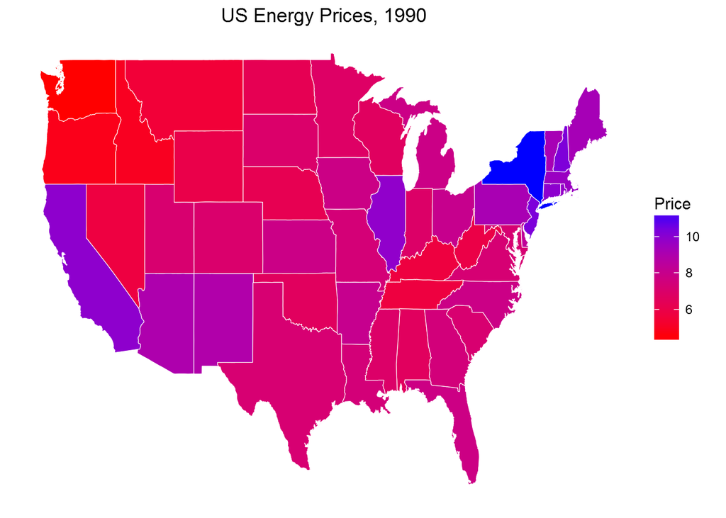

```r
fun.stateplot(1990)
```

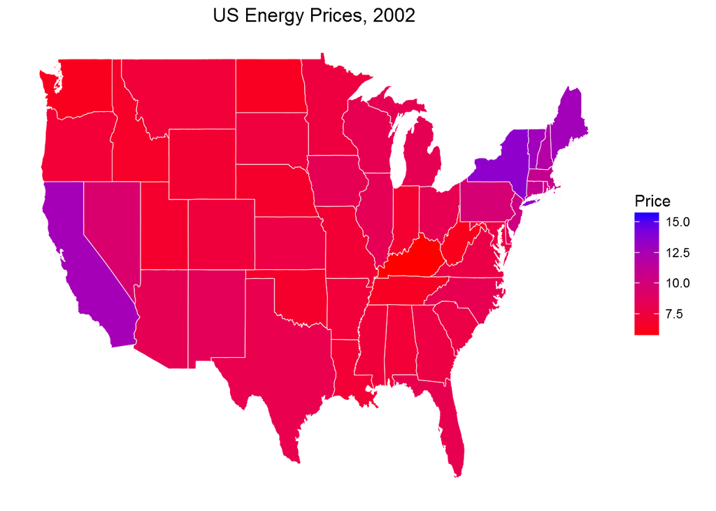

```r
fun.stateplot(2002)
```

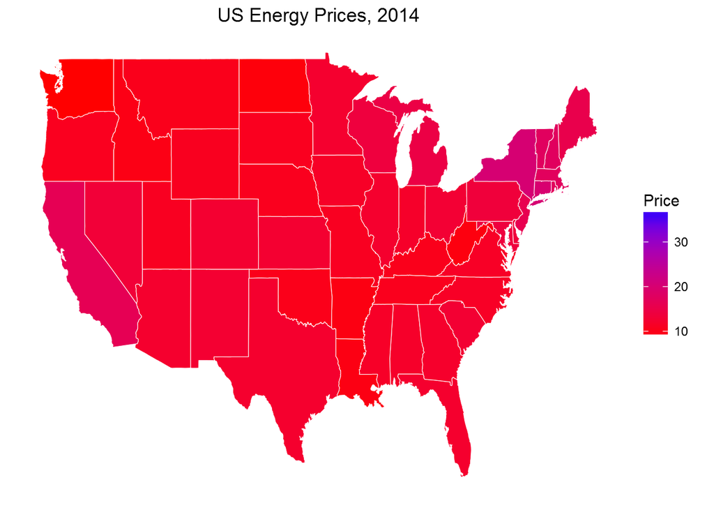

```r
fun.stateplot(2014)
```

Very cool. At first glance, it looks like residential energy prices tightened in most of the country between 1990 and 2014. Is this correct or just due to the scale differences? Could it be a result of deregulation? I will take a look in the next post at some hard numbers to nail down how energy prices have shifted among the states in the 25 year period we have data for.